# DS400: Assignment V: GitHub and the ticketmaster.com API (R)

Max Mohr (Student ID: 6304784)

2023-01-31

GitHub Repository: https://github.com/maxjmohr/MSc_01_DSPM_Assignment05

I hereby acknowledge that the submitted assignment is my own work. During the preparation of this assignment I have worked together with Jakob Zgonc and Felix Koehn.

```r
# load packages
library(ggplot2)
library(httr)
library(rlist)
library(tidyverse)
library(dplyr)
```

### Setting up a new GitHub repository

1. Register on github.com in case you have not done this already.
2. Initialize a new public repository for this assignment on GitHub.
3. For the following exercises of this assignment, follow the standard Git workflow (i.e., pull the latest version of the project to your local computer, then stage, commit, and push all the modifications that you make throughout the project). Every logical programming step should be well documented on GitHub with a meaningful commit message, so that other people (e.g., your course instructor) can follow and understand the development history. You can do this either using Shell commands or a Git GUI of your choice.
4. In the HTML file that you submit, include the hyperlink to the project repository (e.g., https://github. com/yourUserName/yourProjectName)

### Getting to know the API

5. Visit the documentation website for the API provided by ticketmaster.com (see here). Familiarize your- self with the features and functionalities of the Ticketmaster Discovery API. Have a particular look at rate limits.
6. Within the scope of this assignment, you do not have to request your own API key. Instead retrieve a valid key from the API Explorer. This API key enables you to perform the GET requests needed throughout this assignment. Even though this API key is not secret per se (it is publicly visible on the API Explorer website), please comply to the common secrecy practices discussed in the lecture and the tutorial: Treat the API key as a secret token. Your API key should neither appear in the code that you are submitting nor in your public GitHub repository.

```r
# access the key from txt file
ticketmaster_api_key <- readLines("api_keys/ticketmaster_api_key.txt", warn = FALSE)
```

### Interacting with the API - the basics

7. Perform a first GET request, that searches for event venues in Germany (countryCode = “DE”). Extract the content from the response object and inspect the resulting list. Describe what you can see.

```r
# perform get request
api_content <- GET(url = "https://app.ticketmaster.com/discovery/v2/venues?",
                   query = list(apikey = ticketmaster_api_key,
                                countryCode = "DE",
                                locale = "*"))

api_content <- content(api_content)
```

By briefly looking at the content of the get request, we are able to see some of the venues in Germany. At least regarding the few examples we are able to see, the type is indeed a “venue”. Furthermore, te countryCode is “DE”.

However, not all venues have the exact same information displayed in each column. For example, one venue named “Virtual event” doesn’t have any data for the column “address”. Another example is the venue named “Huxleys Neue Welt” has an image while others don’t.

We in total have 12.934 elements that are German venues, displayed over 647 pages. One page displays 20 results.

8. Extract the name, the city, the postalCode and address, as well as the url and the longitude and latitude of the venues to a data frame. This data frame should have the following structure (see pdf).

```r
# Get content of German venues
venues <- GET(url = "https://app.ticketmaster.com/discovery/v2/venues?",
              query = list(apikey = ticketmaster_api_key,
                           countryCode = "DE",
                           locale = "*"))

venues <- content(venues)

# Get the elements per page to later on loop through each venue and get the relevant information
elements_page <- venues[["page"]][["size"]]

# The data we are looking for lies in _embedded/venues
venues <- venues[["_embedded"]][["venues"]]

# Initialize dataframe
venues_df <- data.frame()

for (i in 1:elements_page) {

  # Fill dataframe with values of venue in i
  venues_df_new = data.frame(
    name = venues[[i]][["name"]],
    city = venues[[i]][["city"]][["name"]],
    postalCode = venues[[i]][["postalCode"]],
    address = venues[[i]][["address"]][["line1"]],
    url = venues[[i]][["url"]],
    longitude = venues[[i]][["location"]][["longitude"]],
    latitude = venues[[i]][["location"]][["latitude"]]
  )

  # rbind the results of venue i to the rest of the dataframe
  venues_df <- rbind(venues_df,venues_df_new)

  # Change the formats of some columns
  venues_df$longitude <- as.numeric(venues_df$longitude)
  venues_df$latitude <- as.numeric(venues_df$latitude)
}

venues_df
```

```
##                          name              city postalCode
## 1          Grosse Freiheit 36           Hamburg      22767
## 2                   Gruenspan           Hamburg      22767
## 3           Huxleys Neue Welt            Berlin      10967
## 4             Zentrum am Park      Emmelshausen      56281
## 5    Stadthalle (Theatersaal)           Mülheim      45479
## 6               Schlossgarten          Bruchsal      76646
## 7                  Stadthalle        Hockenheim      68766
## 8                         FZW          Dortmund      44263
## 9                 Arena Trier             Trier      54292
## 10              Eissporthalle         Memmingen      87700
## 11      Stadthalle Gersthofen        Gersthofen      86368
## 12      Feierwerk (Kranhalle)            Munich      81373
## 13       Feierwerk (Hansa 39)            Munich      81373
## 14 Burghof - STIMMEN-Festival           Lörrach      79539
```

[output cut: 69 more lines]

### Interacting with the API - advanced

9. Have a closer look at the list element named page. Did your GET request from exercise (7) return all event locations in Germany? Obviously not - there are of course much more venues in Germany than those contained in this list. Your GET request only yielded the first results page containing the first 20 out of several thousands of venues. Check the API documentation under the section Venue Search. How can you request the venues from the remaining results pages? Iterate over the results pages and perform GET requests for all venues in Germany. After each iteration, extract the seven variables name, city, postalCode, address, url, longitude, and latitude. Join the information in one large data frame. Print the first 10 rows and the shape of the resulting data frame. The resulting data frame should look something like this (note that the exact number of search results may have changed since this document has been last modified) (see pdf).

```r
# this function checks if for a certain variable, its value in a certain column is null
null_check <- function(variable,first_col,second_col = NULL) {

  # for all variables that only have one column input
  if (is.null(second_col)) {

    # first column is null -> NA
    if (is.null(variable[[first_col]])) {

      output <- NA

    # first column is not null -> value
    } else {

      output <- variable[[first_col]]
    }

  # for all variables that have two input columns
  } else {

    # second column is null -> NA
    if (is.null(variable[[first_col]][[second_col]])) {

      output <- NA

    # second column is not null -> value
    } else {

      output <- variable[[first_col]][[second_col]]

    }

    }

  return(output)
}
```

```r
get_country_venues <- function(country_code, api_key) {

  # First get request in order to get the number of pages with at least one result
  setup <- GET(url = "https://app.ticketmaster.com/discovery/v2/venues?",
                query = list(apikey      = api_key,
                             countryCode = country_code,
                             size        = 500,  # set size to 500 so we have to loop through fewer pages
                             locale      = "*"))
  setup <- content(setup)

  # Get the number of pages that have to be looped
  search_pages <- setup[["page"]][["totalPages"]]

  # Initialize dataframe
  venues_df <- data.frame(name = NULL, city = NULL, postalCode = NULL, address = NULL, url = NULL, longitude = NULL, latitude = NULL)

  for (p in 1:search_pages) {

    # Enforce a rate limit as only 5 requests per second possible
    Sys.sleep(1/5+0.00001)

    # Set default value for content_venues to NULL so the while loop is activated
    content_venues <- NULL

    while (is.null(content_venues)) {
      # Get request of page p-1
      content_venues <- GET(url = "https://app.ticketmaster.com/discovery/v2/venues?",
                                query = list(apikey      = api_key,
                                             countryCode = country_code,
                                             size        = 500,  # set size to 500 so we have to loop through fewer pages
                                             locale      = "*",
                                             page        = p-1))
      content_venues <- content(content_venues)

      # The data we are looking for lies in _embedded/venues
      content_venues <- content_venues[["_embedded"]][["venues"]]
    }

    if (length(content_venues) > 0) {

      # Initialize dataframe
      venues <- data.frame(matrix(0, ncol = 7, nrow = length(content_venues)))
      colnames(venues) <- c("name", "city", "postalCode", "address", "url", "longitude", "latitude")

      for (i in 1:length(content_venues)){

        # for rows that don't have values in all columns write NA
        venues$name[i]       <- null_check(content_venues[[i]],"name")
        venues$city[i]       <- null_check(content_venues[[i]],"city","name")
        venues$postalCode[i] <- null_check(content_venues[[i]],"postalCode")
        venues$address[i]    <- null_check(content_venues[[i]],"address","line1")
        venues$url[i]        <- null_check(content_venues[[i]],"url")
        venues$longitude[i]  <- null_check(content_venues[[i]],"location","longitude")
        venues$latitude[i]   <- null_check(content_venues[[i]],"location","latitude")
      }

      venues_df <- rbind(venues_df,venues)

    }

  }

  # Change the formats of some columns
  venues_df$longitude <- as.numeric(venues_df$longitude)
  venues_df$latitude  <- as.numeric(venues_df$latitude)

  return(venues_df)

}
```

```r
german_venues_df <- get_country_venues('DE', ticketmaster_api_key)

head(german_venues_df,10)
```

```
##                        name         city postalCode               address
## 1        Grosse Freiheit 36      Hamburg      22767    Grosse Freiheit 36
## 2                 Gruenspan      Hamburg      22767    Grosse Freiheit 58
## 3         Huxleys Neue Welt       Berlin      10967  Hasenheide 107 – 113
## 4           Zentrum am Park Emmelshausen      56281 Rhein-Mosel-Straße 45
## 5  Stadthalle (Theatersaal)      Mülheim      45479 Theodor-Heuss-Platz 1
## 6             Schlossgarten     Bruchsal      76646      Schloss Bruchsal
## 7                Stadthalle   Hockenheim      68766       Rathausstraße 3
## 8                       FZW     Dortmund      44263       Ritterstraße 20
## 9               Arena Trier        Trier      54292    Fort-Worth-Platz 1
## 10            Eissporthalle    Memmingen      87700   Hühnerbergstraße 19
##                                                                                         url
## 1                                                   http://www.ticketmaster.de/venue/287636
## 2                                                   http://www.ticketmaster.de/venue/287155
## 3                                                   http://www.ticketmaster.de/venue/286842
```

[output cut: 18 more lines]

```r
print(dim(german_venues_df))
```

```
## [1] 12935     7
```

### Visualizing the extracted data

10. Below, you can find code that produces a map of Germany. Add points to the map indicating the locations of the event venues across Germany.

```r
plot_country_venues <- function(venues_df,country,bounds = NULL) {

  # setting out of bounds latitudes to NA
  venues_df[, "latitude"][(venues_df[, "latitude"] < bounds$latitude[1]) |
                        (venues_df[, "latitude"] > bounds$latitude[2])] <- NA

  # setting out of bounds longitudes to NA
  venues_df[, "longitude"][(venues_df[, "longitude"] < bounds$longitude[1]) |
                        (venues_df[, "longitude"] > bounds$longitude[2])] <- NA

  ggplot() +

  # Get map
  borders("world", country, colour = "black", fill = "grey90") +

  theme_void() +

  coord_quickmap() +

  # Title and caption
  labs(title = paste("Event locations across", country),
       caption = "Source: ticketmaster.com") +
  theme(title = element_text(size=8, face='bold'),
        plot.caption = element_text(face = "italic")) +

  # Add the points of venues
  geom_point(aes(x = venues_df$longitude, y = venues_df$latitude), color = "blue")
}
```

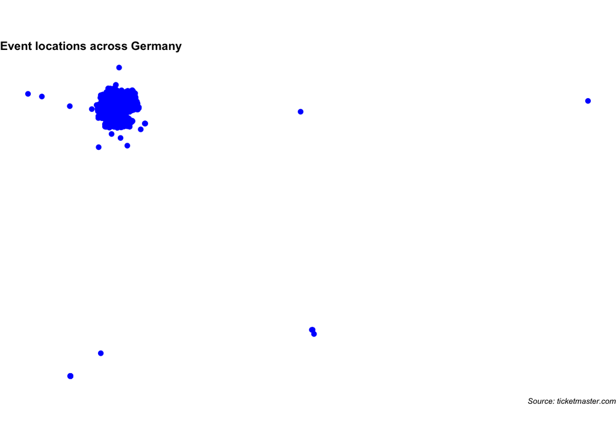

```r
plot_country_venues(german_venues_df, "Germany")
```

11. You will find that some coordinates lie way beyond the German borders and can be assumed to be faulty. Set coordinate values to NA where the value of longitude is outside the range (5.866, 15.042) or where the value of latitude is outside the range (47.270, 55.059) (these coordinate ranges have been derived from the extreme points of Germany as listed on Wikipedia (see here). For extreme points of other countries, see here).

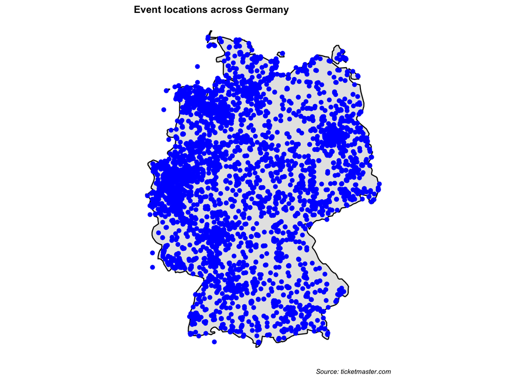

```r
bounds_germany <- list("longitude" = c(5.866, 15.042), "latitude" = c(47.270, 55.059))
plot_country_venues(german_venues_df, "Germany", bounds_germany)
```

### Event locations in other countries

12. Repeat exercises (9)–(11) for another European country of your choice. (Hint: Clean code pays off! If you have coded the exercises efficiently, only very few adaptions need to be made.)

```r
italian_venues_df <- get_country_venues('IT', ticketmaster_api_key)

head(italian_venues_df,10)
```

```
##                           name            city postalCode
## 1                    Live Club           Milan      20056
## 2                        ITALY Gardone Riviera      25083
## 3                        ITALY          Rubano      35030
## 4                        ITALY            Rome      00187
## 5                        ITALY          Modena      41121
## 6                        ITALY          Rivoli      10098
## 7  Teatro Nazionale CheBanca!           Milano      20149
## 8                Visarno Arena        Florence      50144
## 9                   Stadthalle           Bozen      39100
## 10             Arena di Verona          Verona      37121
##                                     address
## 1                  Via Giuseppe Mazzini, 58
## 2                     Corso Zanardelli, 196
## 3         via Liguria 1  Sarmeola di Rubano
```

[output cut: 29 more lines]

```r
print(dim(italian_venues_df))
```

```
## [1] 301   7
```

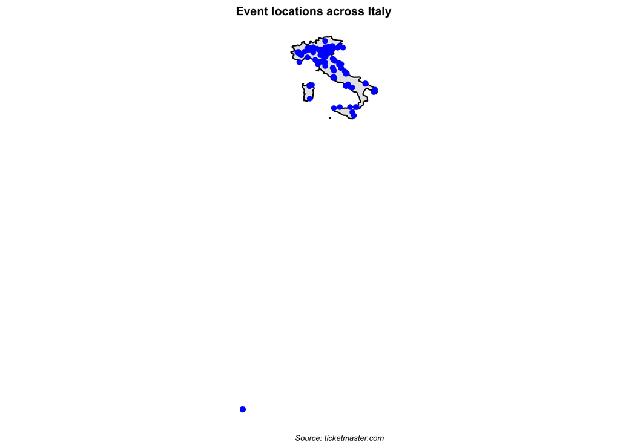

```r
plot_country_venues(italian_venues_df, "Italy")
```

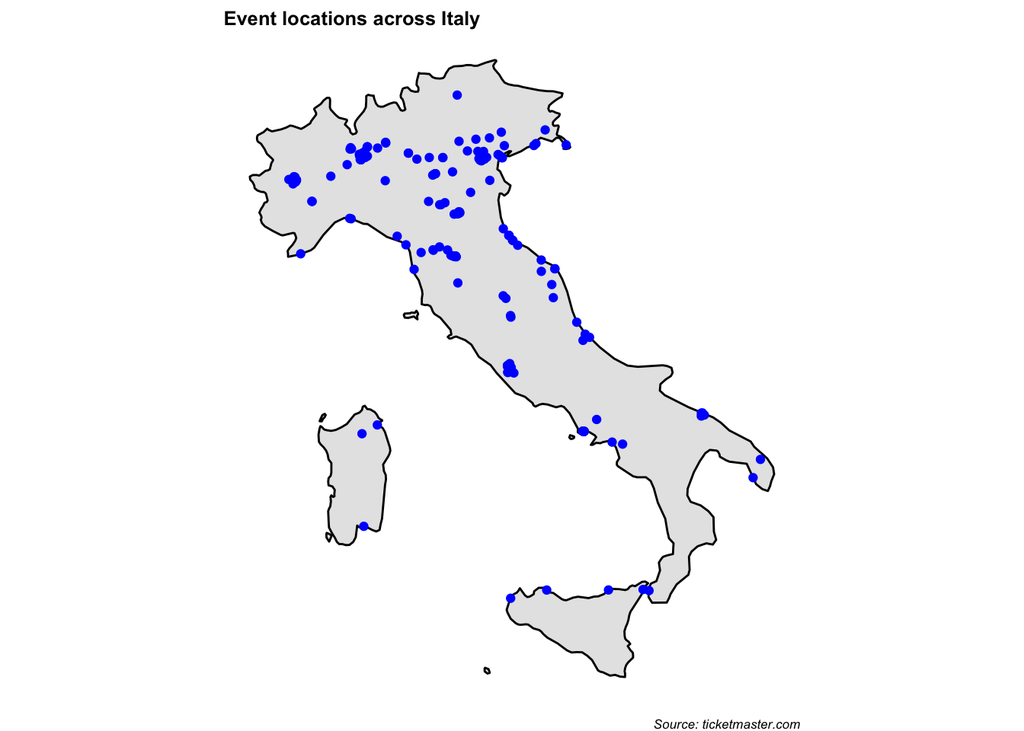

```r
bounds_italy <- list("longitude" = c(6.616667, 18.516667), "latitude" = c(37.933333, 47.083333))
plot_country_venues(italian_venues_df, "Italy", bounds_italy)
```